# LRM Assignment 2

232807001

2023-12-04

## Read in dataset

```r
library(readxl)
df=read_excel("REG1.xlsx")
nrow(df)
```

```
## [1] 48
```

```r
ncol(df)
```

```
## [1] 5
```

## About the data

- A1, Petrol tax (cents per gallon)
- A2, Average income (dollars)
- A3, Paved Highways (miles)
- A4, Proportion of population with driver’s licenses
- B, Consumption of petrol (millions of gallons)

## Descriptives

```r
library(psych)
describe(df)
```

```
##    vars  n    mean      sd  median trimmed     mad     min      max    range
## A1    1 48    7.67    0.95    7.50    7.66    0.74    5.00    10.00     5.00
## A2    2 48 4241.83  573.62 4298.00 4235.12  702.75 3063.00  5342.00  2279.00
## A3    3 48 5565.42 3491.51 4735.50 5233.70 3183.14  431.00 17782.00 17351.00
## A4    4 48    0.57    0.06    0.56    0.57    0.05    0.45     0.72     0.27
## B     5 48  576.77  111.89  568.50  568.28   93.40  344.00   968.00   624.00
##    skew kurtosis     se
## A1 0.07     0.06   0.14
## A2 0.10    -0.87  82.80
## A3 1.13     1.74 503.96
## A4 0.61     0.17   0.01
## B  1.02     2.14  16.15
```

```r
attach(df)
summary(A1)
```

```
##    Min. 1st Qu.  Median    Mean 3rd Qu.    Max.
##   5.000   7.000   7.500   7.668   8.125  10.000
```

```r
summary(A3)
```

```
##    Min. 1st Qu.  Median    Mean 3rd Qu.    Max.
##     431    3110    4736    5565    7156   17782
```

```r
shapiro.test(A1)
```

```
##
##  Shapiro-Wilk normality test
##
## data:  A1
## W = 0.90984, p-value = 0.001327
```

```r
shapiro.test(A2)
```

```
##
##  Shapiro-Wilk normality test
##
## data:  A2
## W = 0.97523, p-value = 0.3988
```

```r
shapiro.test(A3)
```

```
##
##  Shapiro-Wilk normality test
##
## data:  A3
## W = 0.92497, p-value = 0.004471
```

```r
shapiro.test(A4)
```

```
##
##  Shapiro-Wilk normality test
##
## data:  A4
## W = 0.96099, p-value = 0.1107
```

### Descriptives for normally distributed variables

|  | n | Mean | SD |
| --- | --- | --- | --- |
| A4 | 48 | 0.57 | 0.06 |
| A2 | 48 | 4241.83 | 573.62 |

### Descriptives for non-normally distributed variables

[output not shown]

## Fit model 1

```r
model1 = lm(B~.,data=df)
summary(model1)
```

```
##
## Call:
## lm(formula = B ~ ., data = df)
##
## Residuals:
##     Min      1Q  Median      3Q     Max
## -122.03  -45.57  -10.66   31.53  234.95
##
## Coefficients:
##               Estimate Std. Error t value Pr(>|t|)
## (Intercept)  3.773e+02  1.855e+02   2.033 0.048207 *
## A1          -3.479e+01  1.297e+01  -2.682 0.010332 *
## A2          -6.659e-02  1.722e-02  -3.867 0.000368 ***
## A3          -2.426e-03  3.389e-03  -0.716 0.477999
## A4           1.336e+03  1.923e+02   6.950 1.52e-08 ***
## ---
## Signif. codes:  0 '***' 0.001 '**' 0.01 '*' 0.05 '.' 0.1 ' ' 1
##
## Residual standard error: 66.31 on 43 degrees of freedom
## Multiple R-squared:  0.6787, Adjusted R-squared:  0.6488
## F-statistic: 22.71 on 4 and 43 DF,  p-value: 3.907e-10
```

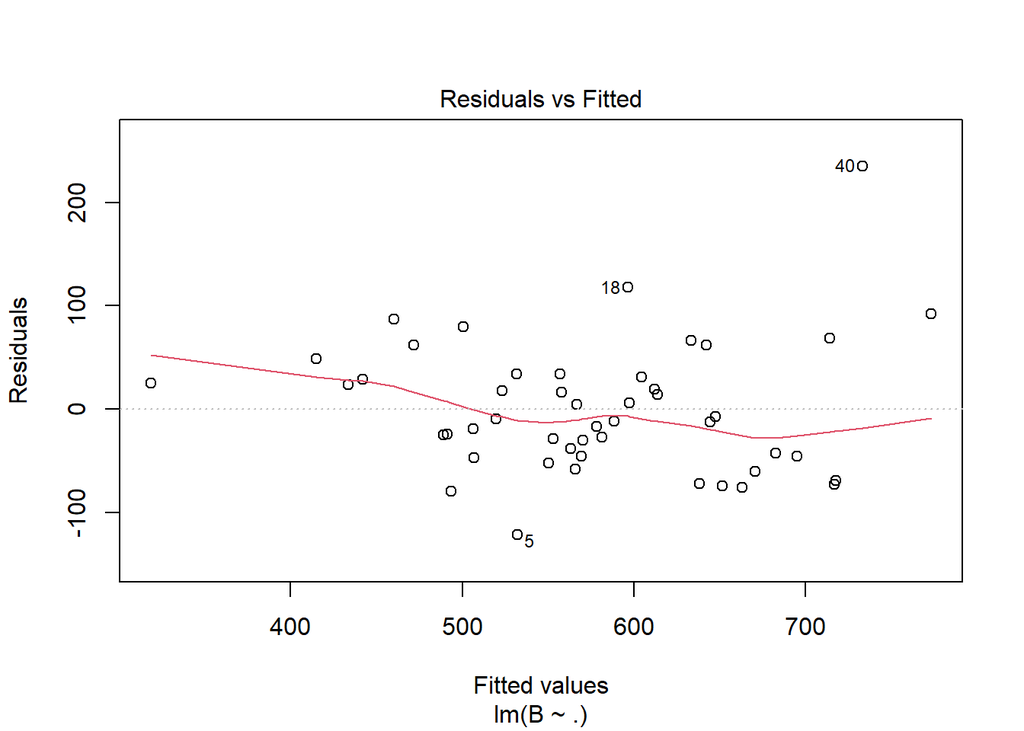

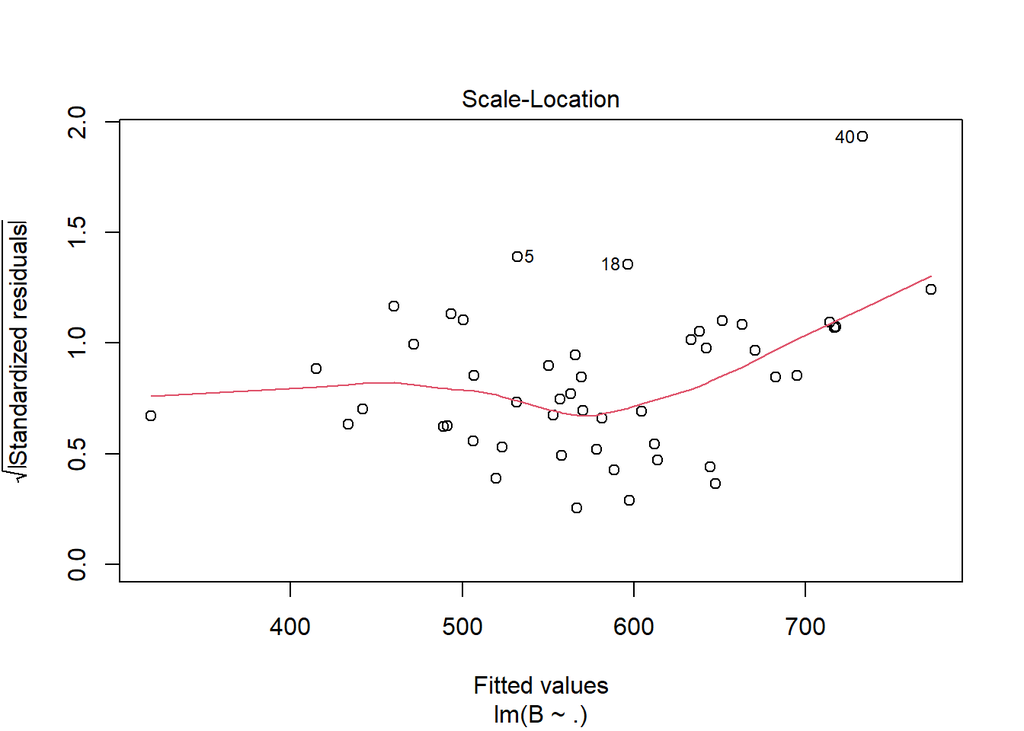

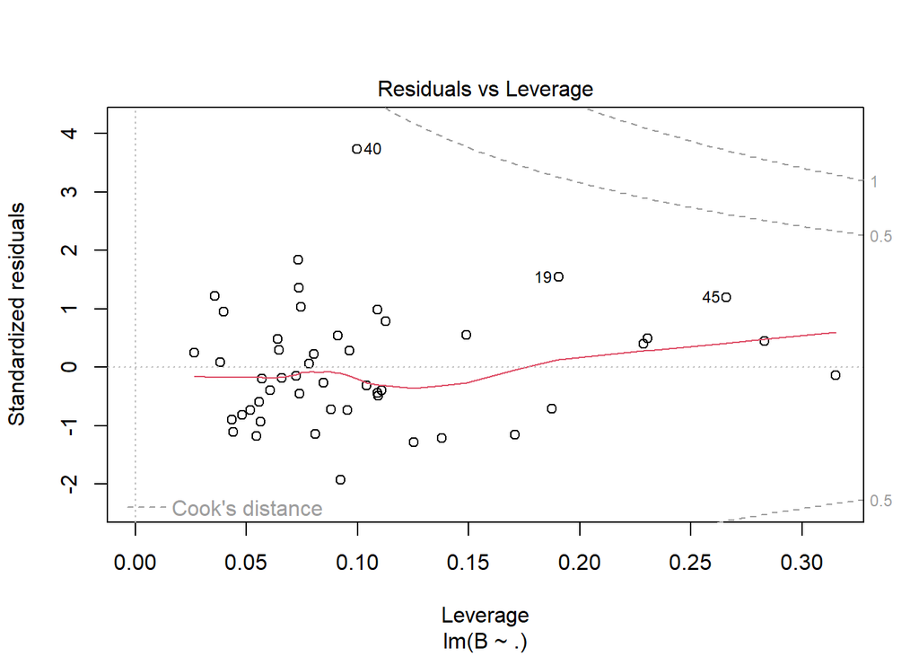

```r
plot(model1)
```

### Influential Observations

```r
cooksD = cooks.distance(model1)
influential <- cooksD[(cooksD > (3 * mean(cooksD,na.rm=TRUE)))]
influential
```

```
##          5         19         40         45
## 0.07590442 0.11190503 0.30896258 0.10445492
```

```r
names_of_influential = names(influential)
names_of_influential
```

```
## [1] "5"  "19" "40" "45"
```

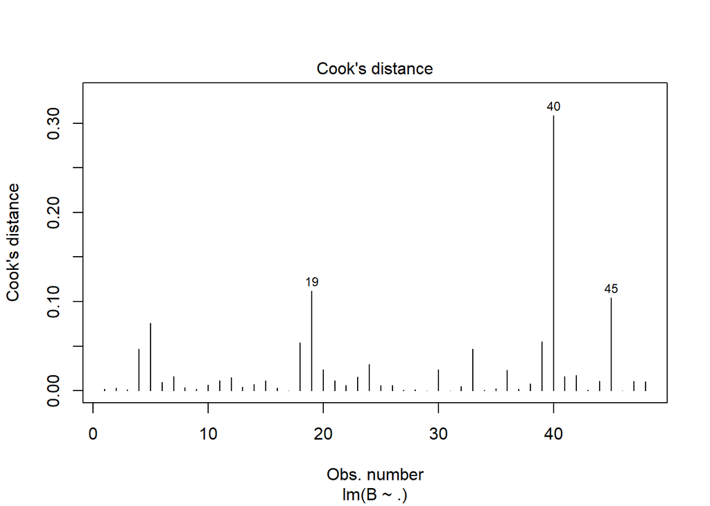

```r
plot(model1,4)
```

Since all points have cooks distance value < 1, there are no influential observations in the model.

### Remove outliers through boxplot

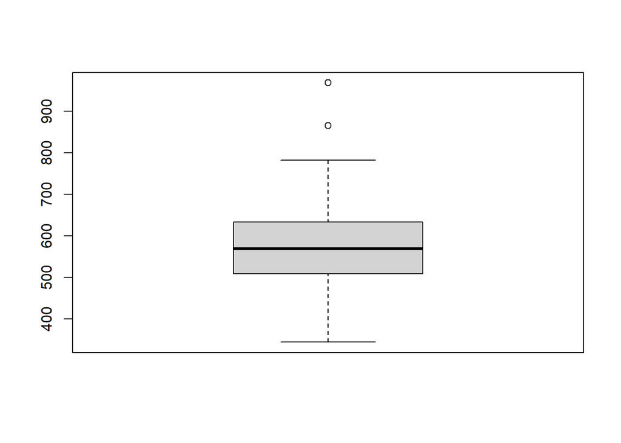

```
## [1] 865 968
```

```r
boxplot(df$B)$out
```

```r
df$B
```

```
##  [1] 541 524 561 414 410 457 344 467 464 498 580 471 525 508 566 635 603 714 865
## [20] 640 649 540 464 547 460 566 577 631 574 534 571 554 577 628 487 644 640 704
## [39] 648 968 587 699 632 591 782 510 610 524
```

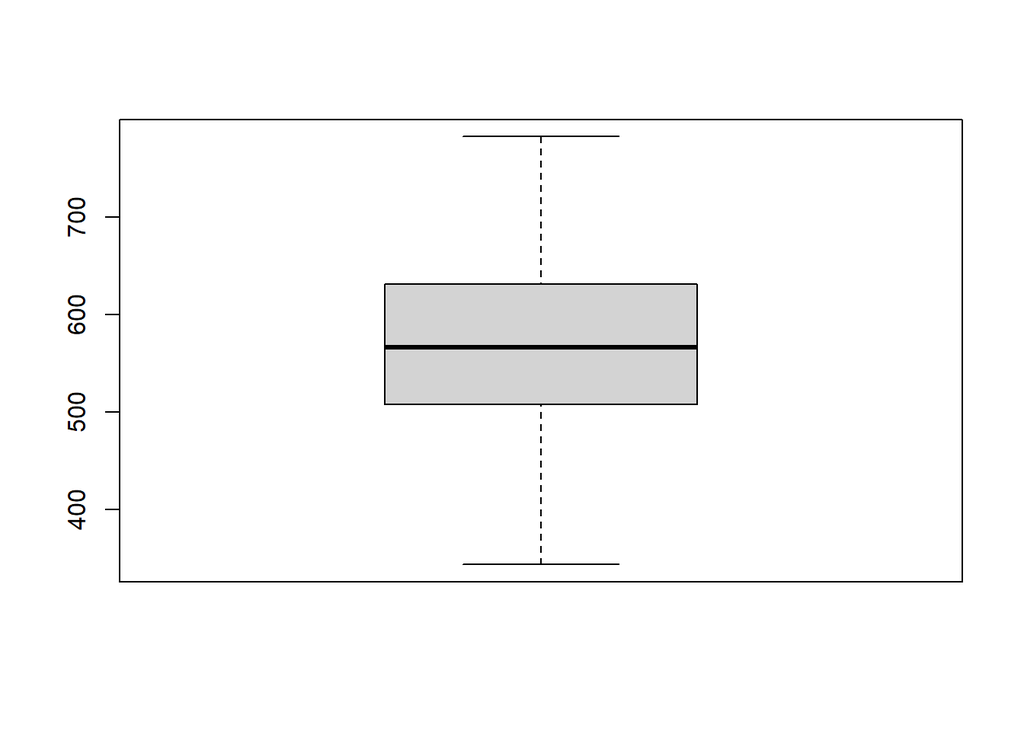

```
## numeric(0)
```

```r
df1 = df[df["B"]!= 865,]
df1 = df1[df1["B"]!=968,]
print(boxplot(df1$B)$out)
```

## Level of Signifance

we use 0.05 level of significance for tests of parameters of regression.

## Fit model 2

```r
model2 = lm(B~.,data=df1)
summary(model2)
```

```
##
## Call:
## lm(formula = B ~ ., data = df1)
##
## Residuals:
##      Min       1Q   Median       3Q      Max
## -118.780  -32.224   -4.668   27.317  120.881
##
## Coefficients:
##               Estimate Std. Error t value Pr(>|t|)
## (Intercept) 549.852345 150.722821   3.648 0.000739 ***
## A1          -32.279588  10.082695  -3.201 0.002642 **
## A2           -0.068287   0.013368  -5.108 7.91e-06 ***
## A3           -0.001686   0.002639  -0.639 0.526566
## A4          989.495903 167.192576   5.918 5.65e-07 ***
## ---
## Signif. codes:  0 '***' 0.001 '**' 0.01 '*' 0.05 '.' 0.1 ' ' 1
##
## Residual standard error: 51.39 on 41 degrees of freedom
## Multiple R-squared:  0.6836, Adjusted R-squared:  0.6527
## F-statistic: 22.15 on 4 and 41 DF,  p-value: 8.53e-10
```

```r
summary(model1)
```

```
##
## Call:
## lm(formula = B ~ ., data = df)
##
## Residuals:
##     Min      1Q  Median      3Q     Max
## -122.03  -45.57  -10.66   31.53  234.95
##
## Coefficients:
##               Estimate Std. Error t value Pr(>|t|)
## (Intercept)  3.773e+02  1.855e+02   2.033 0.048207 *
## A1          -3.479e+01  1.297e+01  -2.682 0.010332 *
## A2          -6.659e-02  1.722e-02  -3.867 0.000368 ***
## A3          -2.426e-03  3.389e-03  -0.716 0.477999
## A4           1.336e+03  1.923e+02   6.950 1.52e-08 ***
## ---
## Signif. codes:  0 '***' 0.001 '**' 0.01 '*' 0.05 '.' 0.1 ' ' 1
##
## Residual standard error: 66.31 on 43 degrees of freedom
## Multiple R-squared:  0.6787, Adjusted R-squared:  0.6488
## F-statistic: 22.71 on 4 and 43 DF,  p-value: 3.907e-10
```

Therefore we will proceed with model1 and check assumptions required for linear regression.

### Checking assumptions

1. Homoskedasticity

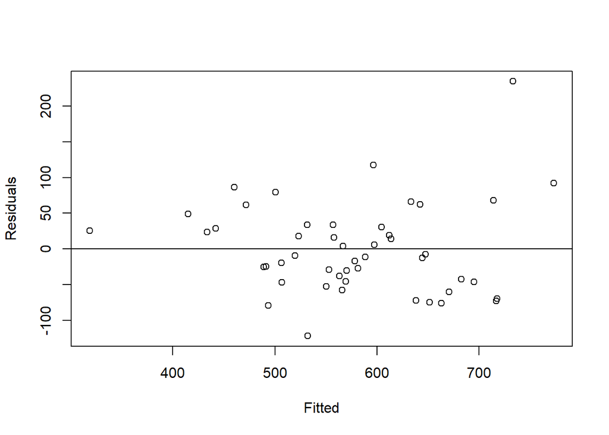

```r
plot(fitted(model1),residuals(model1),xlab="Fitted",ylab="Residuals")
abline(h=0)
```

The plot of residuals vs fitted values has no particular pattern in the plot. Therefore , we apply formal tests for testing heteroskedasticity. They are equally distributed around the zero residual line.

Breusch Pagan Test

```r
library(lmtest)
bptest(model1)
```

```
##
##  studentized Breusch-Pagan test
##
## data:  model1
## BP = 6.5699, df = 4, p-value = 0.1604
```

since p-value = 0.1604 > 0.05, we fail to reject the null hypothesis and conclude that homoskedasticity is present.

2. Normality Of Residuals

```r
plot(model1,2)
```

[output not shown]

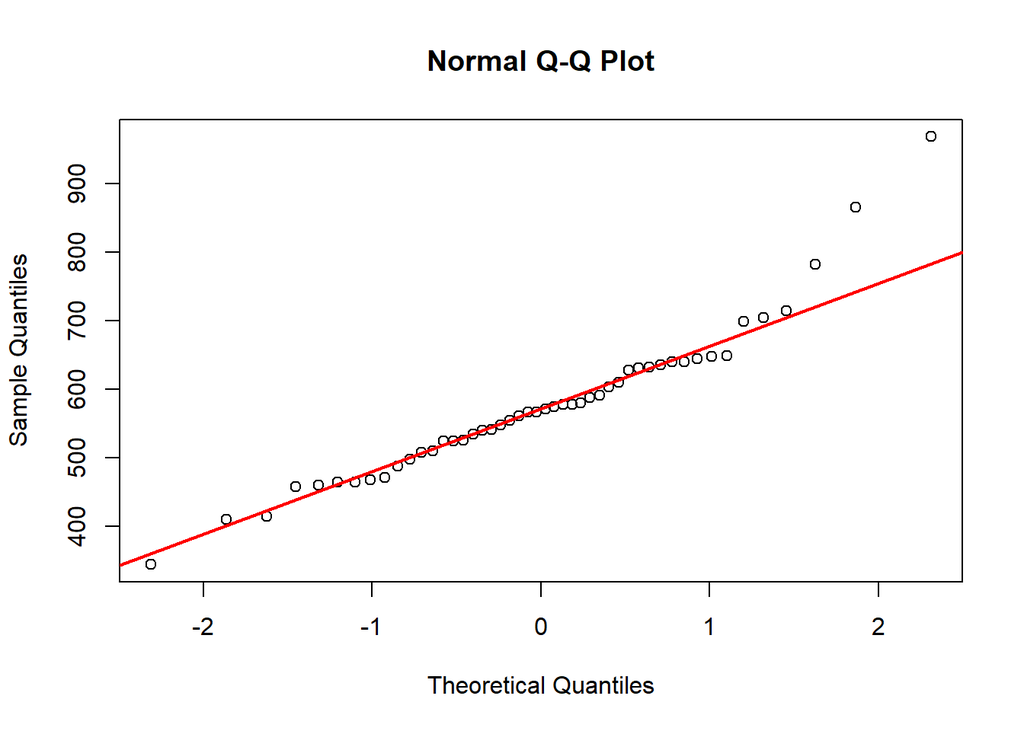

```r
qqnorm(df$B, main="Normal Q-Q Plot")
qqline(df$B, col = "red", lwd = 2)
```

```r
shapiro.test(residuals(model1))
```

```
##
##  Shapiro-Wilk normality test
##
## data:  residuals(model1)
## W = 0.93918, p-value = 0.0151
```

3. Autocorrelation

```r
require(lmtest)
dwtest(model1)
```

```
##
##  Durbin-Watson test
##
## data:  model1
## DW = 2.1708, p-value = 0.6445
## alternative hypothesis: true autocorrelation is greater than 0
```

p-value is greater than 0.05 which leads us to fail to reject the null hypothesis and conclude that the errors are not autocorrelated by durbin watson test.

4. Multicollinearity

```r
library(car)
vif(model1)
```

```
##       A1       A2       A3       A4
## 1.625676 1.043274 1.496937 1.216355
```

Since VIF values of each regressor is less than 5 , we can conclude there is no multicollinearity present in the model.

5. Linearity

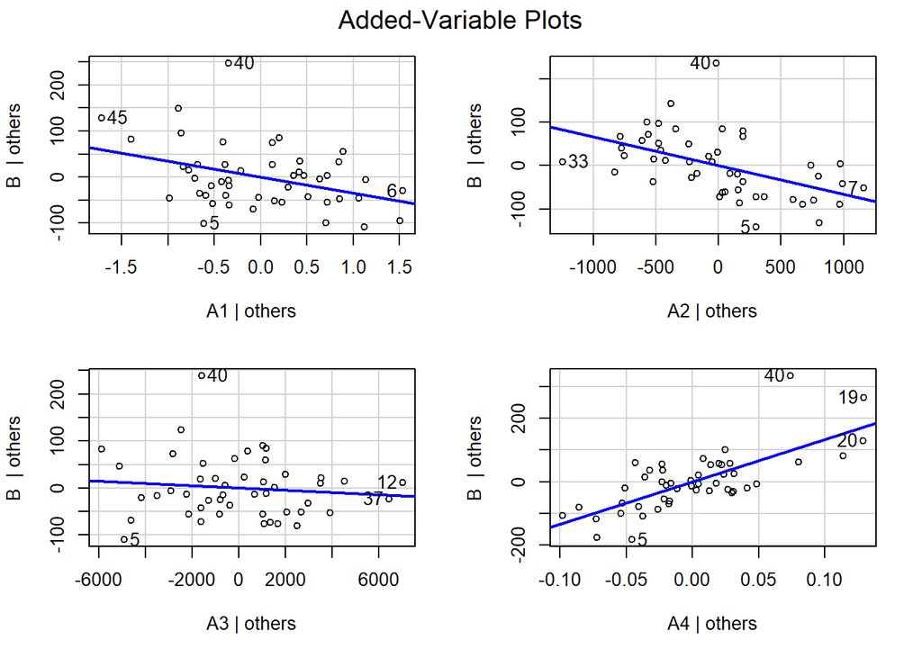

```r
avPlots(model1)
```

From scatter plots for each independent variable vs dependent variable, there is linear relationship b/w each of them. We can still there is an extreme outlier in the response variable (40th observation with value 968 - identified using boxplot earlier.). We can try removing it and checking if there is improvement in the model.

### Stepwise Regression

```r
intercept_only <- lm(B ~ 1, data=df)
all <- lm(B ~ ., data=df)
both <- step(intercept_only, direction='both', scope=formula(all), trace=0)
both$anova
```

```
##   Step Df  Deviance Resid. Df Resid. Dev      AIC
## 1      NA        NA        47   588366.5 453.8674
## 2 + A4 -1 287448.01        46   300918.5 423.6829
## 3 + A2 -1  75874.07        45   225044.4 411.7369
## 4 + A1 -1  33741.95        44   191302.5 405.9397
```

```r
model3 = both
summary(model3)
```

```
##
## Call:
## lm(formula = B ~ A4 + A2 + A1, data = df)
##
## Residuals:
##     Min      1Q  Median      3Q     Max
## -110.10  -51.22  -12.89   24.49  238.77
##
## Coefficients:
##               Estimate Std. Error t value Pr(>|t|)
## (Intercept)  307.32790  156.83067   1.960  0.05639 .
## A4          1374.76841  183.66954   7.485 2.24e-09 ***
## A2            -0.06802    0.01701  -3.999  0.00024 ***
## A1           -29.48381   10.58358  -2.786  0.00785 **
## ---
## Signif. codes:  0 '***' 0.001 '**' 0.01 '*' 0.05 '.' 0.1 ' ' 1
##
## Residual standard error: 65.94 on 44 degrees of freedom
## Multiple R-squared:  0.6749, Adjusted R-squared:  0.6527
## F-statistic: 30.44 on 3 and 44 DF,  p-value: 8.235e-11
```

```r
summary(model1)
```

```
##
## Call:
## lm(formula = B ~ ., data = df)
##
## Residuals:
##     Min      1Q  Median      3Q     Max
## -122.03  -45.57  -10.66   31.53  234.95
##
## Coefficients:
##               Estimate Std. Error t value Pr(>|t|)
## (Intercept)  3.773e+02  1.855e+02   2.033 0.048207 *
## A1          -3.479e+01  1.297e+01  -2.682 0.010332 *
## A2          -6.659e-02  1.722e-02  -3.867 0.000368 ***
## A3          -2.426e-03  3.389e-03  -0.716 0.477999
## A4           1.336e+03  1.923e+02   6.950 1.52e-08 ***
## ---
## Signif. codes:  0 '***' 0.001 '**' 0.01 '*' 0.05 '.' 0.1 ' ' 1
##
## Residual standard error: 66.31 on 43 degrees of freedom
## Multiple R-squared:  0.6787, Adjusted R-squared:  0.6488
## F-statistic: 22.71 on 4 and 43 DF,  p-value: 3.907e-10
```

### Model Adequacy

Model 3 explains about 65.27 % of the variability in regression.

Also the Wald’s t-test shows us that A3 is not significantly contributing towards response in model 1, which has been removed in model 3 leading to better significance of A1.

Let us check for residual plots for model 3.

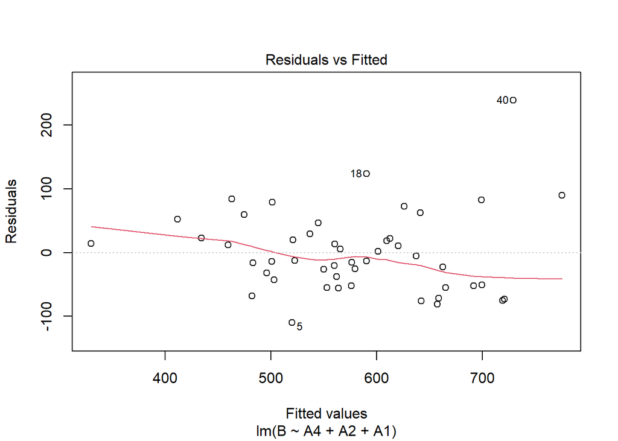

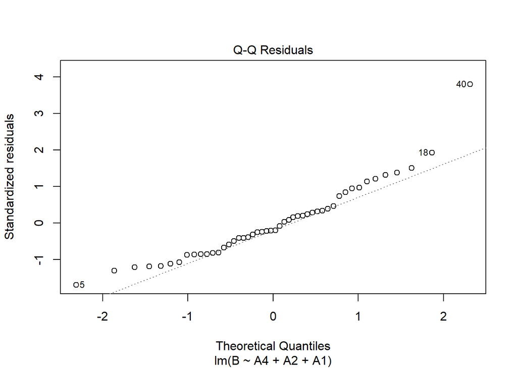

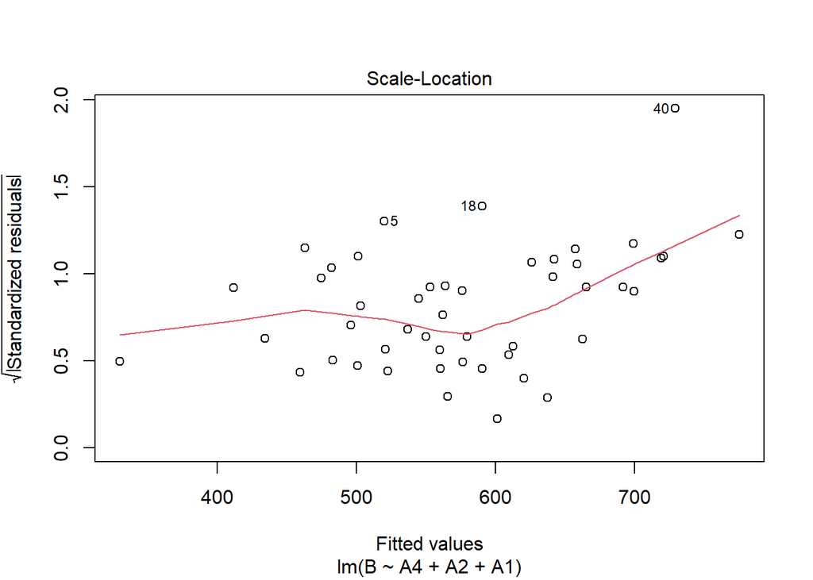

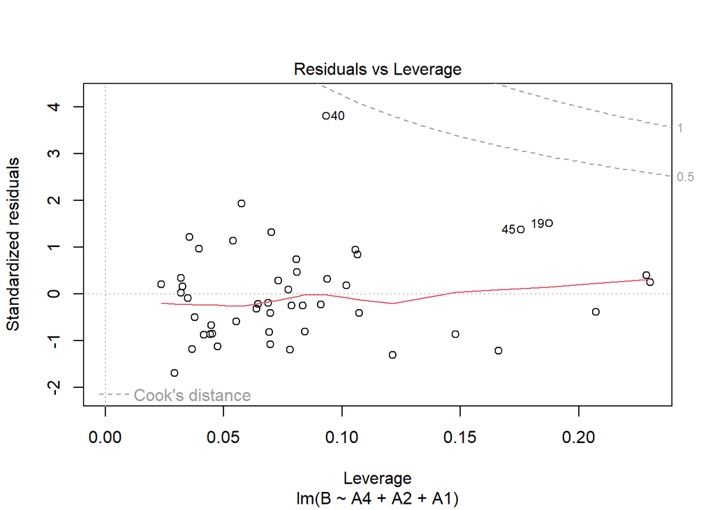

```r
plot(model3)
```

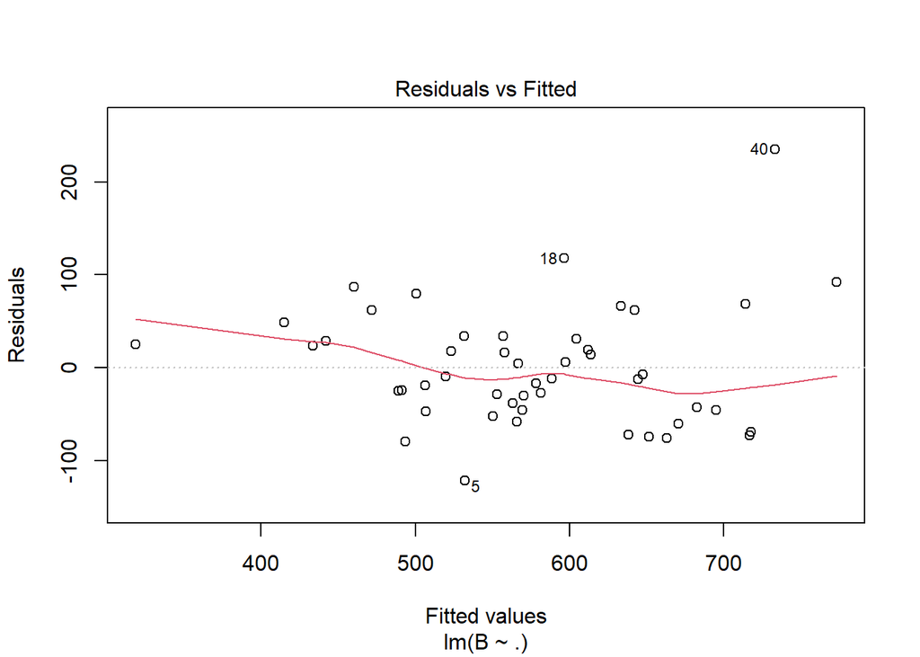

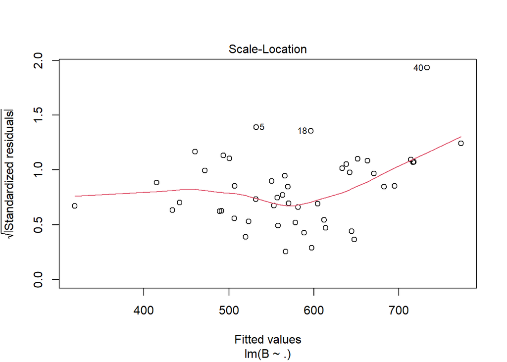

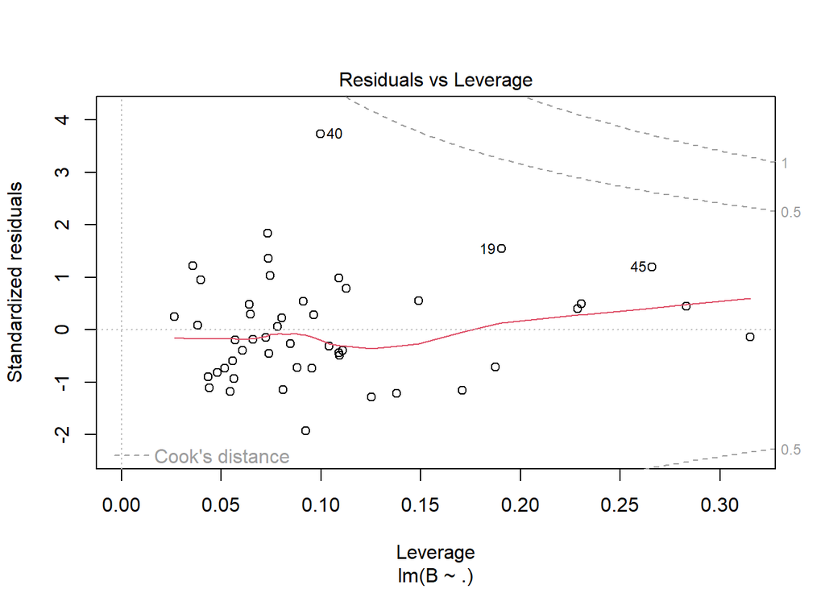

```r
plot(model1)
```

```r
shapiro.test(residuals(model3))
```

```
##
##  Shapiro-Wilk normality test
##
## data:  residuals(model3)
## W = 0.9282, p-value = 0.005858
```

The null hypothesis is rejected and hence we conclude residuals are not normally distributed for model 3.

### Interactions

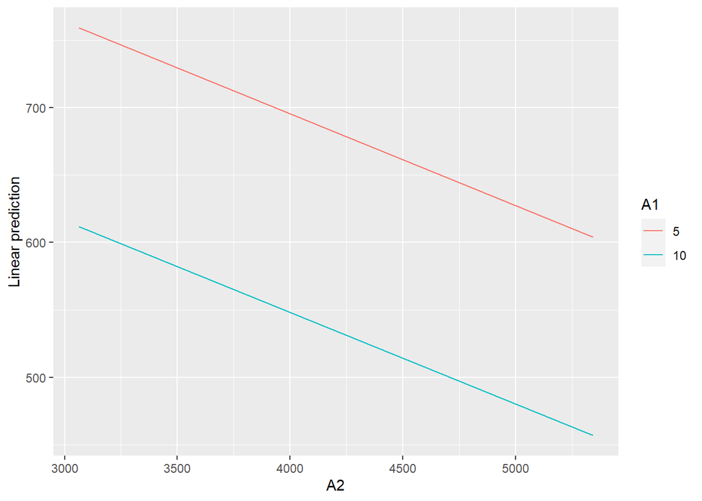

```r
library(emmeans)
emmip(model3, A1 ~ A2, cov.reduce=range)
```

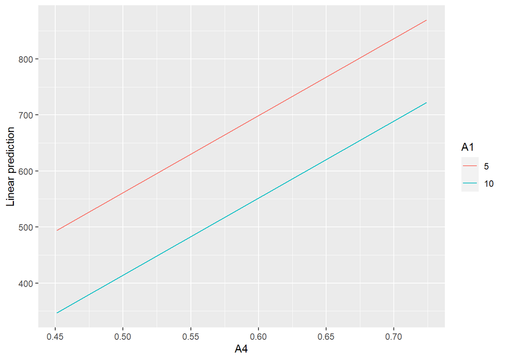

```r
emmip(model3, A1 ~ A4, cov.reduce=range)
```

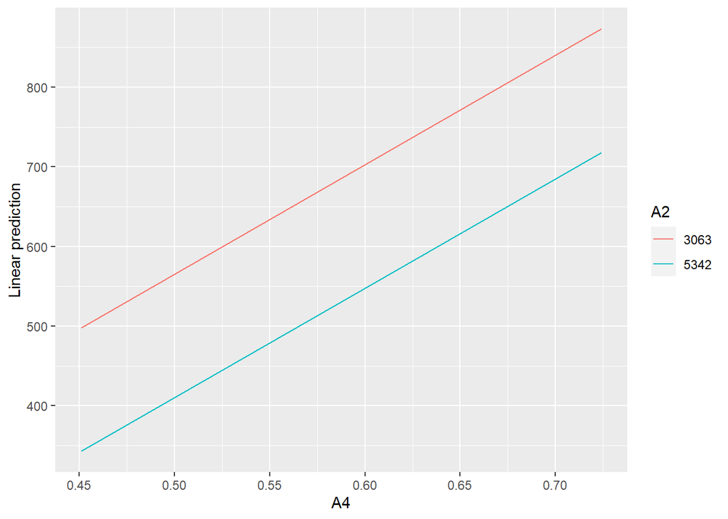

```r
emmip(model3, A2 ~ A4, cov.reduce=range)
```

There are no interactions present between regressors. Therefore we wont go for creating new models with any interactions.

The final fitted multiple linear regression model is given as follows :

$$\widehat{y} = \widehat{\beta_{0}} + \widehat{\beta_{1}}\space x_{1} +
\widehat{\beta_{2}}\space x_{2} + \widehat{\beta_{3}}\space x_{3} \\
where \space \beta_{0} = intercept \\
x_{1} = petrol\space tax(cents\space per\space gallon) \\
x_{2} = average\space income(dollars) \\
x_{3} = proportion\space of\space population\space with\space
their\space driver's\space licenses \\
y = consumption\space of\space petrol (millions\space of\space gallons)$$

```r
summary(model3)
```

```
##
## Call:
## lm(formula = B ~ A4 + A2 + A1, data = df)
##
## Residuals:
##     Min      1Q  Median      3Q     Max
## -110.10  -51.22  -12.89   24.49  238.77
##
## Coefficients:
##               Estimate Std. Error t value Pr(>|t|)
## (Intercept)  307.32790  156.83067   1.960  0.05639 .
## A4          1374.76841  183.66954   7.485 2.24e-09 ***
## A2            -0.06802    0.01701  -3.999  0.00024 ***
## A1           -29.48381   10.58358  -2.786  0.00785 **
## ---
## Signif. codes:  0 '***' 0.001 '**' 0.01 '*' 0.05 '.' 0.1 ' ' 1
##
## Residual standard error: 65.94 on 44 degrees of freedom
## Multiple R-squared:  0.6749, Adjusted R-squared:  0.6527
## F-statistic: 30.44 on 3 and 44 DF,  p-value: 8.235e-11
```

Interpretation :

1. Intercept : is not interpretable since petrol tax cannot be made equal to zero and zero proportion of population with driver’s license does not make sense.
2. Petrol tax (cents per gallon) : for one cent per gallon increase in petrol tax , the petrol consumption is expected to decrease by 29.48 million gallons adjusting for other regressors.
3. Average income (dollars) : for one dollar increase in average income, the petrol consumption is expected to decrease by 0.07 million gallons adjusting for other regressors.
4. Proportion of population with driving license : for unit increase in this proportion , the petrol consumption is expected to increase by 1374.77 million gallons adjusting for other regressors.

Therefore, it can be concluded that proportion of population with driving license seems cause greater change in petrol consumption in the country. A good solution would be to stop usage of vehicles older than 17 years to reduce pollution caused by outdated and inefficient engine models and promote public transport by increasing their numbers and enabling better connections and routes between various places.

### Prediction using model on train data

```r
df1 = data.frame(A1=df$A1,
                 A2=df$A2,
                 A3=df$A3,
                 A4=df$A4)
head(df1)
```

```
##     A1   A2   A3    A4
## 1  9.0 3571 1976 0.525
## 2  9.0 4092 1250 0.572
## 3  9.0 3865 1586 0.580
## 4  7.5 4870 2351 0.529
## 5  8.0 4399  431 0.544
## 6 10.0 5342 1333 0.571
```

```r
head(predict(model3,df1),5)
```

```
##        1        2        3        4        5
## 520.8174 549.9916 576.4309 482.1805 520.0989
```

```r
head(df$B,5)
```

```
## [1] 541 524 561 414 410
```